# Joe Peanasky

Data Scientist - Behavioral Scientist

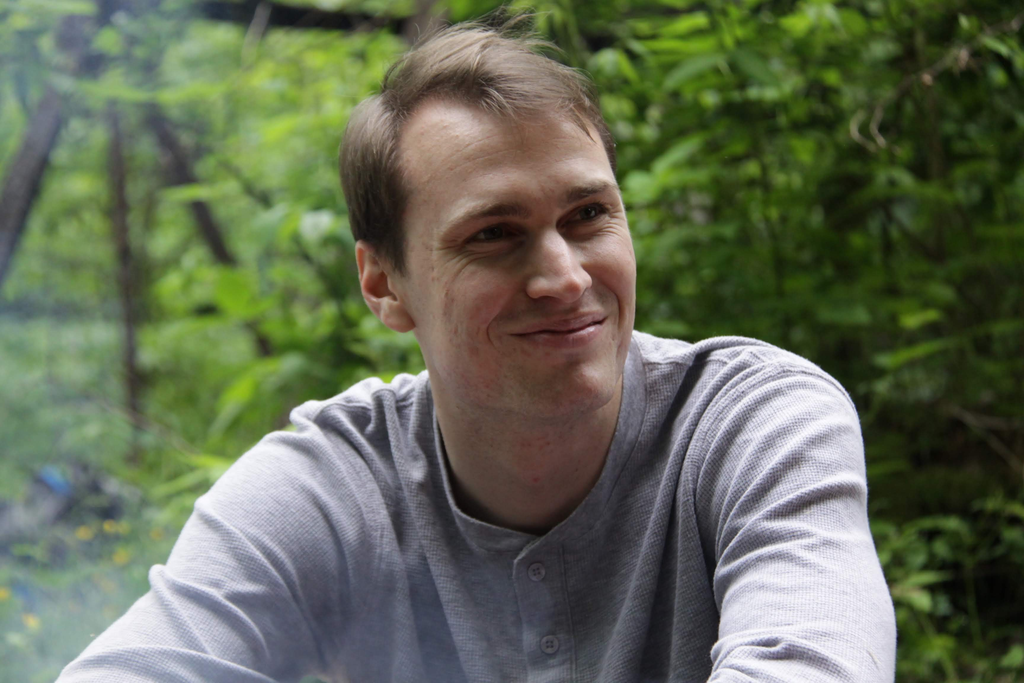

As I finish up my Master in Behavioral and Decision Sciences I am already excited for my next opportunity to learn and grow. My focus for now is continuing to improve my data science skills. I have been using R and SQL for over 4 years and recently picked up Python. From simple analytics, regressions, and dashboard creations to a variety of machine learning techniques, the more data science I learn the more excited I become. Ideally, I can find an opportunity to leverage both my data skills and my understanding of human behavior to shape the world into a more efficient and positive place.

Beyond my academic and professional aspirations, I am ever curious individual always trying to explore and master new skills. Looking through this website you’ll find photos from my adventures traveling the world and experiencing new cultures. Wherever I end up in life I hope to pursue my passions and hobbies including soccer, baking, and photography.